# Risk Factor Analysis

## Outcome Variable

**Outcome Variable:** ever_swasted

## Predictor Variables

**Intervention Variable:** exclfeed36

**Adjustment Set:**

- arm
- sex
- brthmon
- W_mage
- meducyrs
- feducyrs
- hhwealth_quart
- hfoodsec
- W_mhtcm
- W_mwtkg
- W_mbmi
- vagbrth
- W_gagebrth
- W_birthwt
- W_birthlen
- W_nrooms
- W_nchldlt5
- month
- W_parity
- impfloor
- impsan
- safeh20
- delta_W_mage
- delta_meducyrs
- delta_feducyrs
- delta_hhwealth_quart
- delta_hfoodsec
- delta_W_mhtcm
- delta_W_mwtkg
- delta_W_mbmi
- delta_vagbrth
- delta_W_gagebrth
- delta_W_birthwt
- delta_W_birthlen
- delta_W_nrooms
- delta_W_nchldlt5
- delta_month
- delta_W_parity
- delta_impfloor
- delta_impsan
- delta_safeh20

## Stratifying Variables

The analysis was stratified on these variable(s):

- agecat
- studyid
- country

## Data Summary

| agecat | studyid | country | exclfeed36 | ever_swasted | n_cell | n |
| --- | --- | --- | --- | --- | --- | --- |
| 0-24 months (no birth wast) | CMC-V-BCS-2002 | INDIA | 1 | 0 | 9 | 9 |
| 0-24 months (no birth wast) | CMC-V-BCS-2002 | INDIA | 1 | 1 | 0 | 9 |
| 0-24 months (no birth wast) | CMC-V-BCS-2002 | INDIA | 0 | 0 | 0 | 9 |
| 0-24 months (no birth wast) | CMC-V-BCS-2002 | INDIA | 0 | 1 | 0 | 9 |
| 0-24 months (no birth wast) | EE | PAKISTAN | 1 | 0 | 4 | 9 |
| 0-24 months (no birth wast) | EE | PAKISTAN | 1 | 1 | 0 | 9 |
| 0-24 months (no birth wast) | EE | PAKISTAN | 0 | 0 | 4 | 9 |
| 0-24 months (no birth wast) | EE | PAKISTAN | 0 | 1 | 1 | 9 |
| 0-24 months (no birth wast) | GMS-Nepal | NEPAL | 1 | 0 | 330 | 524 |
| 0-24 months (no birth wast) | GMS-Nepal | NEPAL | 1 | 1 | 90 | 524 |
| 0-24 months (no birth wast) | GMS-Nepal | NEPAL | 0 | 0 | 74 | 524 |
| 0-24 months (no birth wast) | GMS-Nepal | NEPAL | 0 | 1 | 30 | 524 |
| 0-24 months (no birth wast) | IRC | INDIA | 1 | 0 | 0 | 4 |
| 0-24 months (no birth wast) | IRC | INDIA | 1 | 1 | 0 | 4 |
| 0-24 months (no birth wast) | IRC | INDIA | 0 | 0 | 3 | 4 |
| 0-24 months (no birth wast) | IRC | INDIA | 0 | 1 | 1 | 4 |
| 0-24 months (no birth wast) | JiVitA-3 | BANGLADESH | 1 | 0 | 9404 | 12568 |
| 0-24 months (no birth wast) | JiVitA-3 | BANGLADESH | 1 | 1 | 370 | 12568 |
| 0-24 months (no birth wast) | JiVitA-3 | BANGLADESH | 0 | 0 | 2698 | 12568 |
| 0-24 months (no birth wast) | JiVitA-3 | BANGLADESH | 0 | 1 | 96 | 12568 |
| 0-24 months (no birth wast) | JiVitA-4 | BANGLADESH | 1 | 0 | 3378 | 4559 |
| 0-24 months (no birth wast) | JiVitA-4 | BANGLADESH | 1 | 1 | 142 | 4559 |
| 0-24 months (no birth wast) | JiVitA-4 | BANGLADESH | 0 | 0 | 989 | 4559 |
| 0-24 months (no birth wast) | JiVitA-4 | BANGLADESH | 0 | 1 | 50 | 4559 |
| 0-24 months (no birth wast) | Keneba | GAMBIA | 1 | 0 | 544 | 1974 |
| 0-24 months (no birth wast) | Keneba | GAMBIA | 1 | 1 | 79 | 1974 |
| 0-24 months (no birth wast) | Keneba | GAMBIA | 0 | 0 | 1115 | 1974 |
| 0-24 months (no birth wast) | Keneba | GAMBIA | 0 | 1 | 236 | 1974 |
| 0-24 months (no birth wast) | LCNI-5 | MALAWI | 1 | 0 | 47 | 271 |
| 0-24 months (no birth wast) | LCNI-5 | MALAWI | 1 | 1 | 0 | 271 |

[output cut: 174 more lines]

The following strata were considered:

- agecat: 0-24 months (no birth wast), studyid: CMC-V-BCS-2002, country: INDIA
- agecat: 0-24 months (no birth wast), studyid: EE, country: PAKISTAN
- agecat: 0-24 months (no birth wast), studyid: GMS-Nepal, country: NEPAL
- agecat: 0-24 months (no birth wast), studyid: IRC, country: INDIA
- agecat: 0-24 months (no birth wast), studyid: JiVitA-3, country: BANGLADESH
- agecat: 0-24 months (no birth wast), studyid: JiVitA-4, country: BANGLADESH
- agecat: 0-24 months (no birth wast), studyid: Keneba, country: GAMBIA
- agecat: 0-24 months (no birth wast), studyid: LCNI-5, country: MALAWI
- agecat: 0-24 months (no birth wast), studyid: MAL-ED, country: BANGLADESH
- agecat: 0-24 months (no birth wast), studyid: MAL-ED, country: BRAZIL
- agecat: 0-24 months (no birth wast), studyid: MAL-ED, country: INDIA
- agecat: 0-24 months (no birth wast), studyid: MAL-ED, country: NEPAL
- agecat: 0-24 months (no birth wast), studyid: MAL-ED, country: PERU
- agecat: 0-24 months (no birth wast), studyid: MAL-ED, country: SOUTH AFRICA
- agecat: 0-24 months (no birth wast), studyid: MAL-ED, country: TANZANIA, UNITED REPUBLIC OF
- agecat: 0-24 months (no birth wast), studyid: PROVIDE, country: BANGLADESH
- agecat: 0-24 months (no birth wast), studyid: SAS-FoodSuppl, country: INDIA
- agecat: 0-6 months (no birth wast), studyid: CMC-V-BCS-2002, country: INDIA
- agecat: 0-6 months (no birth wast), studyid: EE, country: PAKISTAN
- agecat: 0-6 months (no birth wast), studyid: GMS-Nepal, country: NEPAL
- agecat: 0-6 months (no birth wast), studyid: IRC, country: INDIA
- agecat: 0-6 months (no birth wast), studyid: JiVitA-3, country: BANGLADESH
- agecat: 0-6 months (no birth wast), studyid: JiVitA-4, country: BANGLADESH
- agecat: 0-6 months (no birth wast), studyid: Keneba, country: GAMBIA
- agecat: 0-6 months (no birth wast), studyid: LCNI-5, country: MALAWI
- agecat: 0-6 months (no birth wast), studyid: MAL-ED, country: BANGLADESH
- agecat: 0-6 months (no birth wast), studyid: MAL-ED, country: BRAZIL
- agecat: 0-6 months (no birth wast), studyid: MAL-ED, country: INDIA
- agecat: 0-6 months (no birth wast), studyid: MAL-ED, country: NEPAL
- agecat: 0-6 months (no birth wast), studyid: MAL-ED, country: PERU
- agecat: 0-6 months (no birth wast), studyid: MAL-ED, country: SOUTH AFRICA
- agecat: 0-6 months (no birth wast), studyid: MAL-ED, country: TANZANIA, UNITED REPUBLIC OF
- agecat: 0-6 months (no birth wast), studyid: PROVIDE, country: BANGLADESH
- agecat: 0-6 months (no birth wast), studyid: SAS-FoodSuppl, country: INDIA
- agecat: 6-24 months, studyid: CMC-V-BCS-2002, country: INDIA
- agecat: 6-24 months, studyid: EE, country: PAKISTAN
- agecat: 6-24 months, studyid: GMS-Nepal, country: NEPAL
- agecat: 6-24 months, studyid: IRC, country: INDIA
- agecat: 6-24 months, studyid: JiVitA-3, country: BANGLADESH
- agecat: 6-24 months, studyid: JiVitA-4, country: BANGLADESH
- agecat: 6-24 months, studyid: Keneba, country: GAMBIA
- agecat: 6-24 months, studyid: LCNI-5, country: MALAWI
- agecat: 6-24 months, studyid: MAL-ED, country: BANGLADESH
- agecat: 6-24 months, studyid: MAL-ED, country: BRAZIL
- agecat: 6-24 months, studyid: MAL-ED, country: INDIA
- agecat: 6-24 months, studyid: MAL-ED, country: NEPAL
- agecat: 6-24 months, studyid: MAL-ED, country: PERU
- agecat: 6-24 months, studyid: MAL-ED, country: SOUTH AFRICA
- agecat: 6-24 months, studyid: MAL-ED, country: TANZANIA, UNITED REPUBLIC OF
- agecat: 6-24 months, studyid: PROVIDE, country: BANGLADESH
- agecat: 6-24 months, studyid: SAS-FoodSuppl, country: INDIA

### Dropped Strata

Some strata were dropped due to rare outcomes:

- agecat: 0-24 months (no birth wast), studyid: CMC-V-BCS-2002, country: INDIA
- agecat: 0-24 months (no birth wast), studyid: EE, country: PAKISTAN
- agecat: 0-24 months (no birth wast), studyid: IRC, country: INDIA
- agecat: 0-24 months (no birth wast), studyid: LCNI-5, country: MALAWI
- agecat: 0-24 months (no birth wast), studyid: MAL-ED, country: BANGLADESH
- agecat: 0-24 months (no birth wast), studyid: MAL-ED, country: BRAZIL
- agecat: 0-24 months (no birth wast), studyid: MAL-ED, country: INDIA
- agecat: 0-24 months (no birth wast), studyid: MAL-ED, country: NEPAL
- agecat: 0-24 months (no birth wast), studyid: MAL-ED, country: PERU
- agecat: 0-24 months (no birth wast), studyid: MAL-ED, country: SOUTH AFRICA
- agecat: 0-24 months (no birth wast), studyid: MAL-ED, country: TANZANIA, UNITED REPUBLIC OF
- agecat: 0-24 months (no birth wast), studyid: PROVIDE, country: BANGLADESH
- agecat: 0-24 months (no birth wast), studyid: SAS-FoodSuppl, country: INDIA
- agecat: 0-6 months (no birth wast), studyid: CMC-V-BCS-2002, country: INDIA
- agecat: 0-6 months (no birth wast), studyid: EE, country: PAKISTAN
- agecat: 0-6 months (no birth wast), studyid: IRC, country: INDIA
- agecat: 0-6 months (no birth wast), studyid: LCNI-5, country: MALAWI
- agecat: 0-6 months (no birth wast), studyid: MAL-ED, country: BANGLADESH
- agecat: 0-6 months (no birth wast), studyid: MAL-ED, country: BRAZIL
- agecat: 0-6 months (no birth wast), studyid: MAL-ED, country: INDIA
- agecat: 0-6 months (no birth wast), studyid: MAL-ED, country: NEPAL
- agecat: 0-6 months (no birth wast), studyid: MAL-ED, country: PERU
- agecat: 0-6 months (no birth wast), studyid: MAL-ED, country: SOUTH AFRICA
- agecat: 0-6 months (no birth wast), studyid: MAL-ED, country: TANZANIA, UNITED REPUBLIC OF
- agecat: 0-6 months (no birth wast), studyid: PROVIDE, country: BANGLADESH
- agecat: 0-6 months (no birth wast), studyid: SAS-FoodSuppl, country: INDIA
- agecat: 6-24 months, studyid: CMC-V-BCS-2002, country: INDIA
- agecat: 6-24 months, studyid: EE, country: PAKISTAN
- agecat: 6-24 months, studyid: IRC, country: INDIA
- agecat: 6-24 months, studyid: LCNI-5, country: MALAWI
- agecat: 6-24 months, studyid: MAL-ED, country: BANGLADESH
- agecat: 6-24 months, studyid: MAL-ED, country: BRAZIL
- agecat: 6-24 months, studyid: MAL-ED, country: INDIA
- agecat: 6-24 months, studyid: MAL-ED, country: NEPAL
- agecat: 6-24 months, studyid: MAL-ED, country: PERU
- agecat: 6-24 months, studyid: MAL-ED, country: SOUTH AFRICA
- agecat: 6-24 months, studyid: MAL-ED, country: TANZANIA, UNITED REPUBLIC OF
- agecat: 6-24 months, studyid: PROVIDE, country: BANGLADESH
- agecat: 6-24 months, studyid: SAS-FoodSuppl, country: INDIA

## Methods Detail

We’re interested in the causal parameters $E[Y_a]$ for all values of $a \in \mathcal{A}$. These parameters represent the mean outcome if, possibly contrary to fact, we intervened to set all units to have $A=a$. Under the randomization and positivity assumptions, these are identified by the statistical parameters $\psi_a=E_W[E_{Y|A,W}(Y|A=a,W)]$. In addition, we’re interested in the mean of $Y$, $E[Y]$ under no intervention (the observed mean). We will estimate these parameters by using SuperLearner to fit the relevant likelihood factors – $E_{Y|A,W}(Y|A=a,W)$ and $p(A=a|W)$, and then updating our likelihood fit using a joint TMLE.

For unadjusted analyses ($W=\{\}$), initial likelihoods were estimated using Lrnr_glm to estimate the simple $E(Y|A)$ and Lrnr_mean to estimate $p(A)$. For adjusted analyses, a small library containing Lrnr_glmnet, Lrnr_xgboost, and Lrnr_mean was used.

Having estimated these parameters, we will then use the delta method to estimate relative risks and attributable risks relative to a prespecified baseline level of $A$.

# Results Detail

## Results Plots

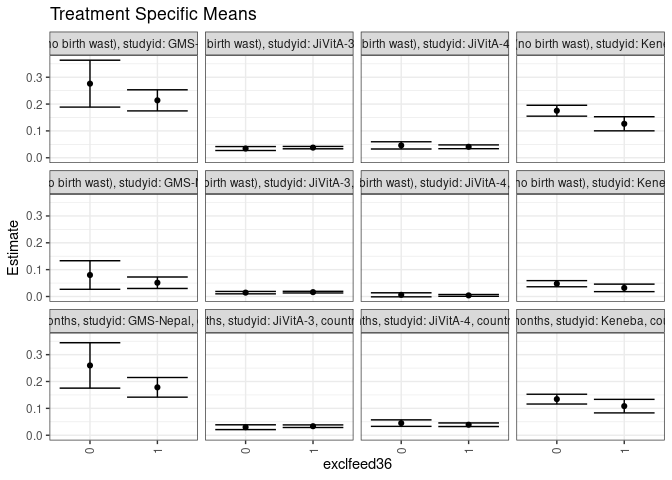

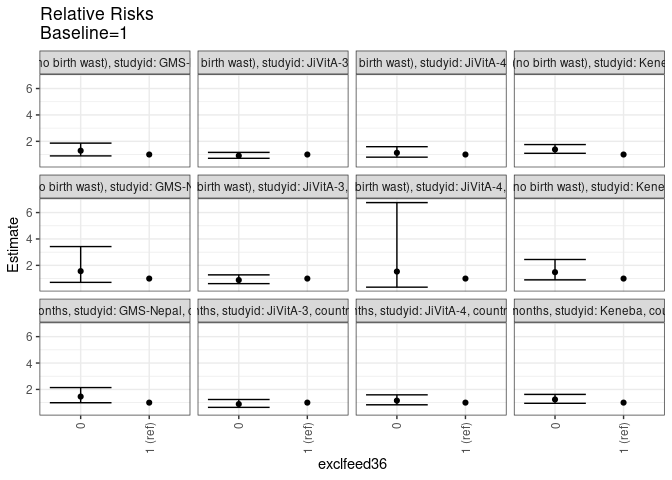

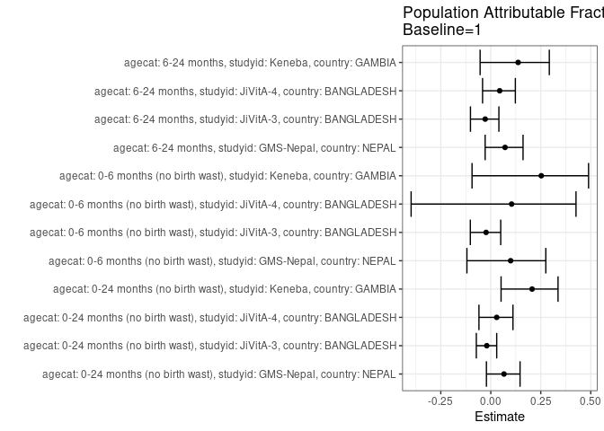

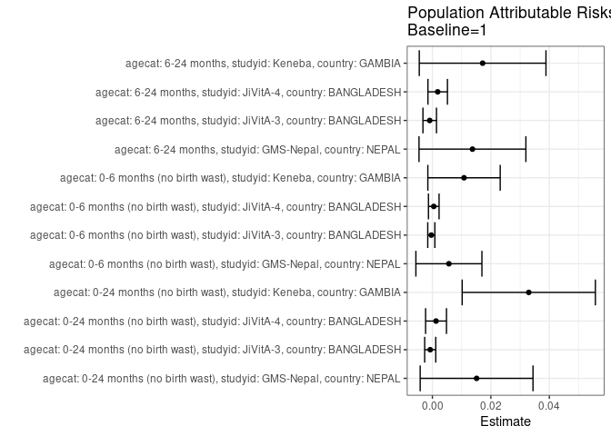

## Results Table

### Parameter: TSM

| agecat | studyid | country | intervention_level | baseline_level | estimate | ci_lower | ci_upper |
| --- | --- | --- | --- | --- | --- | --- | --- |
| 0-24 months (no birth wast) | GMS-Nepal | NEPAL | 1 | NA | 0.2138911 | 0.1745655 | 0.2532167 |
| 0-24 months (no birth wast) | GMS-Nepal | NEPAL | 0 | NA | 0.2760845 | 0.1887349 | 0.3634341 |
| 0-24 months (no birth wast) | JiVitA-3 | BANGLADESH | 1 | NA | 0.0378246 | 0.0334588 | 0.0421903 |
| 0-24 months (no birth wast) | JiVitA-3 | BANGLADESH | 0 | NA | 0.0344581 | 0.0271081 | 0.0418081 |
| 0-24 months (no birth wast) | JiVitA-4 | BANGLADESH | 1 | NA | 0.0408709 | 0.0338246 | 0.0479172 |
| 0-24 months (no birth wast) | JiVitA-4 | BANGLADESH | 0 | NA | 0.0461712 | 0.0326835 | 0.0596590 |
| 0-24 months (no birth wast) | Keneba | GAMBIA | 1 | NA | 0.1266150 | 0.1003483 | 0.1528818 |
| 0-24 months (no birth wast) | Keneba | GAMBIA | 0 | NA | 0.1752417 | 0.1549637 | 0.1955197 |
| 0-6 months (no birth wast) | GMS-Nepal | NEPAL | 1 | NA | 0.0512195 | 0.0298604 | 0.0725786 |
| 0-6 months (no birth wast) | GMS-Nepal | NEPAL | 0 | NA | 0.0800000 | 0.0267753 | 0.1332247 |
| 0-6 months (no birth wast) | JiVitA-3 | BANGLADESH | 1 | NA | 0.0161856 | 0.0130915 | 0.0192797 |
| 0-6 months (no birth wast) | JiVitA-3 | BANGLADESH | 0 | NA | 0.0143649 | 0.0098700 | 0.0188598 |
| 0-6 months (no birth wast) | JiVitA-4 | BANGLADESH | 1 | NA | 0.0040416 | 0.0006666 | 0.0074166 |
| 0-6 months (no birth wast) | JiVitA-4 | BANGLADESH | 0 | NA | 0.0061920 | -0.0013383 | 0.0137222 |
| 0-6 months (no birth wast) | Keneba | GAMBIA | 1 | NA | 0.0320410 | 0.0180519 | 0.0460300 |
| 0-6 months (no birth wast) | Keneba | GAMBIA | 0 | NA | 0.0475718 | 0.0361477 | 0.0589958 |
| 6-24 months | GMS-Nepal | NEPAL | 1 | NA | 0.1783155 | 0.1417373 | 0.2148937 |
| 6-24 months | GMS-Nepal | NEPAL | 0 | NA | 0.2599028 | 0.1753455 | 0.3444600 |
| 6-24 months | JiVitA-3 | BANGLADESH | 1 | NA | 0.0335711 | 0.0287067 | 0.0384355 |
| 6-24 months | JiVitA-3 | BANGLADESH | 0 | NA | 0.0298470 | 0.0208968 | 0.0387972 |
| 6-24 months | JiVitA-4 | BANGLADESH | 1 | NA | 0.0390362 | 0.0323319 | 0.0457406 |
| 6-24 months | JiVitA-4 | BANGLADESH | 0 | NA | 0.0450035 | 0.0328748 | 0.0571322 |
| 6-24 months | Keneba | GAMBIA | 1 | NA | 0.1083498 | 0.0831593 | 0.1335403 |
| 6-24 months | Keneba | GAMBIA | 0 | NA | 0.1343815 | 0.1160774 | 0.1526857 |

### Parameter: E(Y)

| agecat | studyid | country | intervention_level | baseline_level | estimate | ci_lower | ci_upper |
| --- | --- | --- | --- | --- | --- | --- | --- |
| 0-24 months (no birth wast) | GMS-Nepal | NEPAL | NA | NA | 0.2290076 | 0.1929956 | 0.2650196 |
| 0-24 months (no birth wast) | JiVitA-3 | BANGLADESH | NA | NA | 0.0370783 | 0.0333023 | 0.0408543 |
| 0-24 months (no birth wast) | JiVitA-4 | BANGLADESH | NA | NA | 0.0421145 | 0.0360504 | 0.0481786 |
| 0-24 months (no birth wast) | Keneba | GAMBIA | NA | NA | 0.1595745 | 0.1434154 | 0.1757335 |
| 0-6 months (no birth wast) | GMS-Nepal | NEPAL | NA | NA | 0.0568627 | 0.0367445 | 0.0769810 |
| 0-6 months (no birth wast) | JiVitA-3 | BANGLADESH | NA | NA | 0.0158131 | 0.0132056 | 0.0184207 |
| 0-6 months (no birth wast) | JiVitA-4 | BANGLADESH | NA | NA | 0.0045116 | 0.0014181 | 0.0076051 |
| 0-6 months (no birth wast) | Keneba | GAMBIA | NA | NA | 0.0428571 | 0.0338884 | 0.0518259 |
| 6-24 months | GMS-Nepal | NEPAL | NA | NA | 0.1920152 | 0.1583224 | 0.2257081 |
| 6-24 months | JiVitA-3 | BANGLADESH | NA | NA | 0.0326531 | 0.0283158 | 0.0369903 |
| 6-24 months | JiVitA-4 | BANGLADESH | NA | NA | 0.0408475 | 0.0350297 | 0.0466653 |
| 6-24 months | Keneba | GAMBIA | NA | NA | 0.1255252 | 0.1106396 | 0.1404109 |

### Parameter: RR

| agecat | studyid | country | intervention_level | baseline_level | estimate | ci_lower | ci_upper |
| --- | --- | --- | --- | --- | --- | --- | --- |
| 0-24 months (no birth wast) | GMS-Nepal | NEPAL | 1 | 1 | 1.0000000 | 1.0000000 | 1.000000 |
| 0-24 months (no birth wast) | GMS-Nepal | NEPAL | 0 | 1 | 1.2907715 | 0.8941152 | 1.863396 |
| 0-24 months (no birth wast) | JiVitA-3 | BANGLADESH | 1 | 1 | 1.0000000 | 1.0000000 | 1.000000 |
| 0-24 months (no birth wast) | JiVitA-3 | BANGLADESH | 0 | 1 | 0.9109983 | 0.7151542 | 1.160474 |
| 0-24 months (no birth wast) | JiVitA-4 | BANGLADESH | 1 | 1 | 1.0000000 | 1.0000000 | 1.000000 |
| 0-24 months (no birth wast) | JiVitA-4 | BANGLADESH | 0 | 1 | 1.1296845 | 0.8009050 | 1.593431 |
| 0-24 months (no birth wast) | Keneba | GAMBIA | 1 | 1 | 1.0000000 | 1.0000000 | 1.000000 |
| 0-24 months (no birth wast) | Keneba | GAMBIA | 0 | 1 | 1.3840514 | 1.0913193 | 1.755305 |
| 0-6 months (no birth wast) | GMS-Nepal | NEPAL | 1 | 1 | 1.0000000 | 1.0000000 | 1.000000 |
| 0-6 months (no birth wast) | GMS-Nepal | NEPAL | 0 | 1 | 1.5619048 | 0.7122754 | 3.425005 |
| 0-6 months (no birth wast) | JiVitA-3 | BANGLADESH | 1 | 1 | 1.0000000 | 1.0000000 | 1.000000 |
| 0-6 months (no birth wast) | JiVitA-3 | BANGLADESH | 0 | 1 | 0.8875108 | 0.6151085 | 1.280547 |
| 0-6 months (no birth wast) | JiVitA-4 | BANGLADESH | 1 | 1 | 1.0000000 | 1.0000000 | 1.000000 |
| 0-6 months (no birth wast) | JiVitA-4 | BANGLADESH | 0 | 1 | 1.5320654 | 0.3473637 | 6.757254 |
| 0-6 months (no birth wast) | Keneba | GAMBIA | 1 | 1 | 1.0000000 | 1.0000000 | 1.000000 |
| 0-6 months (no birth wast) | Keneba | GAMBIA | 0 | 1 | 1.4847162 | 0.9019033 | 2.444145 |
| 6-24 months | GMS-Nepal | NEPAL | 1 | 1 | 1.0000000 | 1.0000000 | 1.000000 |
| 6-24 months | GMS-Nepal | NEPAL | 0 | 1 | 1.4575446 | 0.9922080 | 2.141120 |
| 6-24 months | JiVitA-3 | BANGLADESH | 1 | 1 | 1.0000000 | 1.0000000 | 1.000000 |
| 6-24 months | JiVitA-3 | BANGLADESH | 0 | 1 | 0.8890693 | 0.6400084 | 1.235053 |
| 6-24 months | JiVitA-4 | BANGLADESH | 1 | 1 | 1.0000000 | 1.0000000 | 1.000000 |
| 6-24 months | JiVitA-4 | BANGLADESH | 0 | 1 | 1.1528650 | 0.8359883 | 1.589852 |
| 6-24 months | Keneba | GAMBIA | 1 | 1 | 1.0000000 | 1.0000000 | 1.000000 |
| 6-24 months | Keneba | GAMBIA | 0 | 1 | 1.2402563 | 0.9472804 | 1.623844 |

### Parameter: PAR

| agecat | studyid | country | intervention_level | baseline_level | estimate | ci_lower | ci_upper |
| --- | --- | --- | --- | --- | --- | --- | --- |
| 0-24 months (no birth wast) | GMS-Nepal | NEPAL | 1 | NA | 0.0151166 | -0.0041738 | 0.0344069 |
| 0-24 months (no birth wast) | JiVitA-3 | BANGLADESH | 1 | NA | -0.0007463 | -0.0026414 | 0.0011489 |
| 0-24 months (no birth wast) | JiVitA-4 | BANGLADESH | 1 | NA | 0.0012436 | -0.0023290 | 0.0048161 |
| 0-24 months (no birth wast) | Keneba | GAMBIA | 1 | NA | 0.0329594 | 0.0101828 | 0.0557360 |
| 0-6 months (no birth wast) | GMS-Nepal | NEPAL | 1 | NA | 0.0056432 | -0.0056457 | 0.0169322 |
| 0-6 months (no birth wast) | JiVitA-3 | BANGLADESH | 1 | NA | -0.0003725 | -0.0015848 | 0.0008398 |
| 0-6 months (no birth wast) | JiVitA-4 | BANGLADESH | 1 | NA | 0.0004700 | -0.0013438 | 0.0022839 |
| 0-6 months (no birth wast) | Keneba | GAMBIA | 1 | NA | 0.0108162 | -0.0015559 | 0.0231882 |
| 6-24 months | GMS-Nepal | NEPAL | 1 | NA | 0.0136997 | -0.0045735 | 0.0319730 |
| 6-24 months | JiVitA-3 | BANGLADESH | 1 | NA | -0.0009180 | -0.0032321 | 0.0013960 |
| 6-24 months | JiVitA-4 | BANGLADESH | 1 | NA | 0.0018113 | -0.0015234 | 0.0051460 |
| 6-24 months | Keneba | GAMBIA | 1 | NA | 0.0171754 | -0.0044862 | 0.0388370 |

### Parameter: PAF

| agecat | studyid | country | intervention_level | baseline_level | estimate | ci_lower | ci_upper |
| --- | --- | --- | --- | --- | --- | --- | --- |
| 0-24 months (no birth wast) | GMS-Nepal | NEPAL | 1 | NA | 0.0660090 | -0.0218388 | 0.1463045 |
| 0-24 months (no birth wast) | JiVitA-3 | BANGLADESH | 1 | NA | -0.0201266 | -0.0724005 | 0.0295993 |
| 0-24 months (no birth wast) | JiVitA-4 | BANGLADESH | 1 | NA | 0.0295285 | -0.0592475 | 0.1108642 |
| 0-24 months (no birth wast) | Keneba | GAMBIA | 1 | NA | 0.2065458 | 0.0513973 | 0.3363191 |
| 0-6 months (no birth wast) | GMS-Nepal | NEPAL | 1 | NA | 0.0992431 | -0.1193952 | 0.2751773 |
| 0-6 months (no birth wast) | JiVitA-3 | BANGLADESH | 1 | NA | -0.0235541 | -0.1024025 | 0.0496547 |
| 0-6 months (no birth wast) | JiVitA-4 | BANGLADESH | 1 | NA | 0.1041859 | -0.3985239 | 0.4261929 |
| 0-6 months (no birth wast) | Keneba | GAMBIA | 1 | NA | 0.2523769 | -0.0938020 | 0.4889932 |
| 6-24 months | GMS-Nepal | NEPAL | 1 | NA | 0.0713471 | -0.0282990 | 0.1613372 |
| 6-24 months | JiVitA-3 | BANGLADESH | 1 | NA | -0.0281139 | -0.1016868 | 0.0405457 |
| 6-24 months | JiVitA-4 | BANGLADESH | 1 | NA | 0.0443429 | -0.0411448 | 0.1228113 |
| 6-24 months | Keneba | GAMBIA | 1 | NA | 0.1368283 | -0.0534009 | 0.2927049 |